# Финальное д/з по R

July 06, 2018

```r
library(tidyverse)
library(rio)
library(skimr)
library(lattice)
library(cluster) # кластерный анализ
library(factoextra) # визуализации kmeans, pca,
library(dendextend) # визуализация дендрограмм
library(corrplot) # визуализация корреляций
library(broom) # метла превращает результаты оценивания моделей в таблички
library(FFTrees) # быстрые деревья
library(margins) # для подсчёта предельных эффектов
library(rpart.plot) # для картинок деревьев
library(plotROC) # визуализация ROC-кривой
library(MLmetrics) # метрики качества
```

# 1 1. Импорт данных по социально - экономическим характеристикам российских городов за 2015 г.

```r
town <- import('town.xlsx')
glimpse(town)
```

```
## Observations: 35
## Variables: 19
## $ X__1                   <chr> "Астрахань", "Барнаул", "Владивосток", ...
## $ Unempl                 <dbl> 4.4724469, 2.6602884, 2.4557802, 5.1569...
## $ wage                   <dbl> 30908.0, 27433.4, 45138.7, 29902.4, 308...
## $ Square_pp              <dbl> 23.8, 22.8, 21.5, 23.1, 26.9, 24.4, 21....
## $ nersery                <dbl> 0.9330855, 0.9048913, 0.8632812, 0.9275...
## $ Doctors                <dbl> 91.3, 49.4, 89.5, 71.8, 86.7, 72.5, 78....
## $ nurse                  <dbl> 162.1, 96.7, 98.4, 131.4, 147.0, 121.5,...
## $ beds                   <dbl> 138.8, 89.9, 147.7, 119.8, 124.6, 136.9...
## $ capacity_of_outpatient <dbl> 293.6, 245.5, 258.9, 351.6, 276.1, 282....
## $ criminals              <dbl> 13.883769, 21.059546, 23.921352, 17.382...
## $ industry               <dbl> 162137.4, 78517.1, 11960.5, 450894.8, 1...
## $ constraction           <dbl> 9574.3, 8612.9, 506.2, 24431.7, 15910.0...
## $ house                  <dbl> 306.2, 608.6, 47.4, 475.1, 1039.2, 1196...
## $ retail_trade_turnover  <dbl> 42459.9, 61360.3, 4902.9, 98747.7, 1048...
## $ catering               <dbl> 779.3, 509.8, 814.1, 1531.5, 1652.0, 57...
## $ investment             <dbl> 82049.6, 18521.0, 6006.1, 101042.1, 632...
## $ transport              <chr> "низкий", "низкий", "средний", "высокий...
## $ ecology                <chr> "высокий", "низкий", "низкий", "высокий...
## $ innovation             <chr> "низкий", "средний", "средний", "средни...
```

# 2 2. Описательный анализ данных

## 2.1 2.1 В наборе данных содержатся набюлдения по 35 российским городам (c населением от 500 тыс. чел. (кроме Москвы и Санкт-Петербурга))

19 переменных, из них 15 - числовых и 4 текстовых: названия городов, уровень развитости транспортной инфраструктуры (transport), оценка экологического состояния города (ecology) и инновационной активности(innovation).

## 2.2 2.2 Определим три последние переменные как факторные(категориальные)

```r
town1 <- town %>% mutate_at(vars(transport, ecology, innovation), factor)
glimpse(town1)
```

```
## Observations: 35
## Variables: 19
## $ X__1                   <chr> "Астрахань", "Барнаул", "Владивосток", ...
## $ Unempl                 <dbl> 4.4724469, 2.6602884, 2.4557802, 5.1569...
## $ wage                   <dbl> 30908.0, 27433.4, 45138.7, 29902.4, 308...
## $ Square_pp              <dbl> 23.8, 22.8, 21.5, 23.1, 26.9, 24.4, 21....
## $ nersery                <dbl> 0.9330855, 0.9048913, 0.8632812, 0.9275...
## $ Doctors                <dbl> 91.3, 49.4, 89.5, 71.8, 86.7, 72.5, 78....
## $ nurse                  <dbl> 162.1, 96.7, 98.4, 131.4, 147.0, 121.5,...
## $ beds                   <dbl> 138.8, 89.9, 147.7, 119.8, 124.6, 136.9...
## $ capacity_of_outpatient <dbl> 293.6, 245.5, 258.9, 351.6, 276.1, 282....
## $ criminals              <dbl> 13.883769, 21.059546, 23.921352, 17.382...
## $ industry               <dbl> 162137.4, 78517.1, 11960.5, 450894.8, 1...
## $ constraction           <dbl> 9574.3, 8612.9, 506.2, 24431.7, 15910.0...
## $ house                  <dbl> 306.2, 608.6, 47.4, 475.1, 1039.2, 1196...
## $ retail_trade_turnover  <dbl> 42459.9, 61360.3, 4902.9, 98747.7, 1048...
## $ catering               <dbl> 779.3, 509.8, 814.1, 1531.5, 1652.0, 57...
## $ investment             <dbl> 82049.6, 18521.0, 6006.1, 101042.1, 632...
## $ transport              <fct> низкий, низкий, средний, высокий, средн...
## $ ecology                <fct> высокий, низкий, низкий, высокий, высок...
## $ innovation             <fct> низкий, средний, средний, средний, высо...
```

## 2.3 2.3 Графический анализ данных

```r
#library(DataExplorer)
#create_report(town1)
```

Описательные статистики данных

```r
skim(town1)
```

```
## Skim summary statistics
##  n obs: 35
##  n variables: 19
##
## Variable type: character
##  variable missing complete  n min max empty n_unique
##      X__1       0       35 35   3  16     0       35
##
## Variable type: factor
##    variable missing complete  n n_unique                       top_counts
##     ecology       0       35 35        3 сре: 14, низ: 11, выс: 10, NA: 0
##  innovation       0       35 35        3   сре: 17, выс: 9, низ: 9, NA: 0
##   transport       0       35 35        3 сре: 13, выс: 11, низ: 11, NA: 0
##  ordered
##    FALSE
##    FALSE
##    FALSE
##
## Variable type: numeric
##                variable missing complete  n      mean        sd       p0
##                    beds       0       35 35    120.08     25.04    59
##  capacity_of_outpatient       0       35 35    290.51     55.93   109.4
##                catering       0       35 35   2109.59   1642.58    13.3
##            constraction       0       35 35  16218.6   12274.56   506.2
##               criminals       0       35 35     18.59      5.11     5.61
##                 Doctors       0       35 35     71.94     14.35    34.8
##                   house       0       35 35    646.58    422.61    47.4
##                industry       0       35 35 257969.73 166766.35  9742.3
##              investment       0       35 35  56487.62  35154.4   4337.6
##                 nersery       0       35 35      0.85      0.09     0.65
##                   nurse       0       35 35    128.3      19.32    88.2
##   retail_trade_turnover       0       35 35  82776     47873.94  3495.7
##               Square_pp       0       35 35     23.85      2.67    14.4
##                  Unempl       0       35 35      4.35      2.18     0.91
##                    wage       0       35 35  34134.48   5447.38 27387.6
##        p25       p50       p75      p100     hist
##     111.7     120.1     135.9     197.3  ▂▁▂▇▅▁▁▁
##     267.5     289.9     318.95    379.4  ▁▁▁▁▅▇▃▃
##     833.95   1652      2887.3    7410.1  ▇▇▅▂▃▁▁▁
##    8594.15  13135.4   21396.8   63567.8  ▅▇▃▃▁▁▁▁
##      14.98     19.4      22.57     26.34 ▂▁▃▅▆▆▇▅
##      68.2      72.9      79.8      94.6  ▂▂▁▂▆▇▃▃
##     367.45    556.5     793.45   2009.5  ▅▇▇▂▂▁▁▁
##  127961.25 231689.1  355027.6  674094.6  ▅▇▆▆▅▂▁▂
##   25948.65  56408.2   90873.7  117093.3  ▅▇▃▃▃▃▅▃
##       0.79      0.86      0.93      1.05 ▁▃▇▅▇▅▅▁
##     117.55    131.7     139.6     167.6  ▂▂▃▆▇▅▂▂
##   51136.3   61360.3  110513.9  211796.4  ▁▇▃▃▂▂▁▁
##      22.8      23.3      24.7      30.7  ▁▁▁▃▇▃▂▁
##       3.11      3.96      5.09     11.74 ▂▅▇▃▁▁▁▁
##   30110.7   32711     36924.65  46959.6  ▇▇▅▆▂▃▁▃
```

Средняя з/п по городам в 2015 г. составляла 34134 руб. в месяц, уровень безработицы - 4.35% и т.д. По значениям факторных переменных города разбиты на три уровня: низкий, средний, высокий.

Гистограмма для оценки уровня экологии в городах

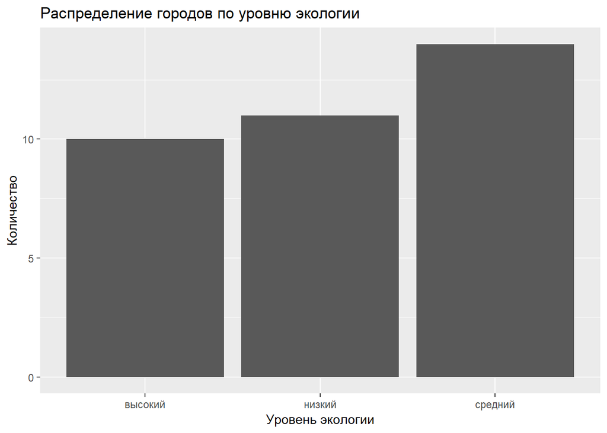

```r
qplot(data = town1, x = ecology)  +
  labs(x = 'Уровень экологии', y = 'Количество', title = 'Распределение городов по уровню экологии')
```

Диаграммы рассеяния: Количество больничных коек и врачей на 10000 человек в городе

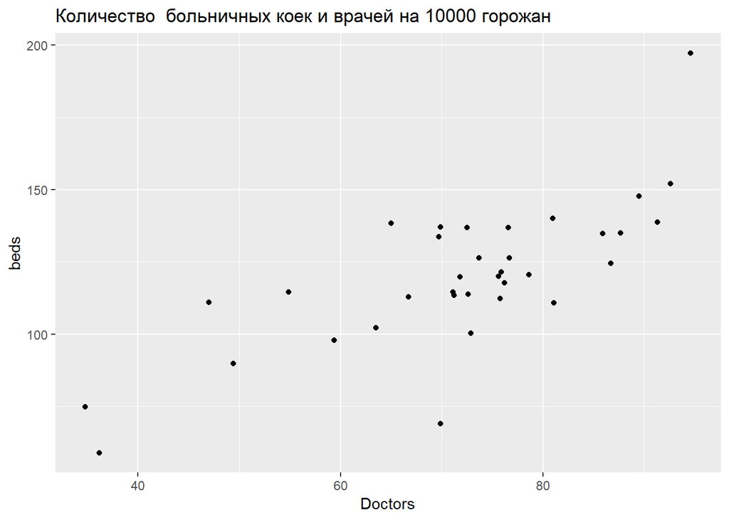

```r
qplot(data = town1, x = Doctors, y = beds) + labs(title = "Количество  больничных коек и врачей на 10000 горожан")
```

Диаграммы рассеяния: Мощность амбулаторно-поликлинических учреждений, количество больничных коек и врачей на 10000 населения города

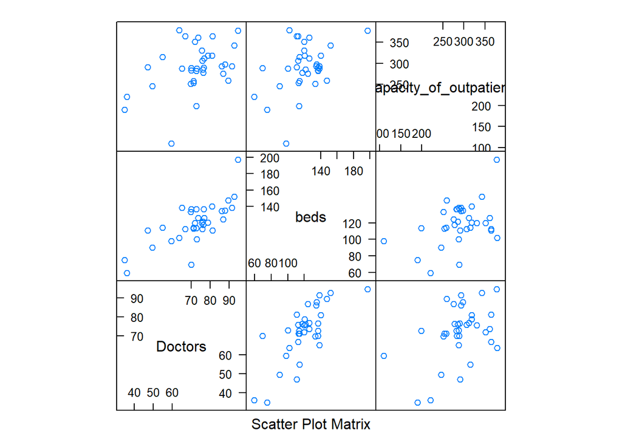

```r
library(lattice) # загружаем пакет
splom(town1[1:35, c(6, 8, 9)]) # строим диаграммы рассеяния для 1000 наблюдений
```

Визуализация корреляционной матрицы количественных переменных

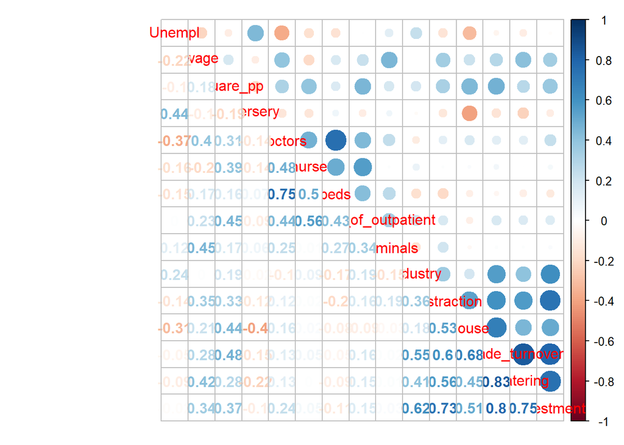

```r
library(corrplot)
town2 <- town1 %>% dplyr::select(-ecology, -transport, -innovation) %>% column_to_rownames(var = 'X__1')   #убираем факторные переменные и определяем текстовую переменную названия городов как название строк
town_cor <- cor(town2)
corrplot.mixed(town_cor)
```

# 3 3. Кластеризация

Стандартизируем все числовые переменные с помощью функции `scale()`.

```r
town3 <- mutate_if(town1, is.numeric, ~ as.vector(scale(.)))  %>% dplyr::select(-ecology, -transport, -innovation) %>% column_to_rownames(var = 'X__1')  #стандартизируем переменные и определяем текстовую переменную названия городов как название строк
glimpse(town3)
```

```
## Observations: 35
## Variables: 15
## $ Unempl                 <dbl> 0.05439195, -0.77748866, -0.87136923, 0...
## $ wage                   <dbl> -0.59229915, -1.23014734, 2.02009546, -...
## $ Square_pp              <dbl> -0.02036181, -0.39544786, -0.88305973, ...
## $ nersery                <dbl> 0.87443620, 0.56266122, 0.10253201, 0.8...
## $ Doctors                <dbl> 1.348862319, -1.570852206, 1.223433055,...
## $ nurse                  <dbl> 1.7496711, -1.6355010, -1.5475072, 0.16...
## $ beds                   <dbl> 0.747620321, -1.205000127, 1.103005229,...
## $ capacity_of_outpatient <dbl> 0.055174388, -0.804881928, -0.565282040...
## $ criminals              <dbl> -0.91978019, 0.48380694, 1.04357825, -0...
## $ industry               <dbl> -0.57465026, -1.07607215, -1.47517305, ...
## $ constraction           <dbl> -0.54130661, -0.61963118, -1.28007825, ...
## $ house                  <dbl> -0.80542439, -0.08987020, -1.41781006, ...
## $ retail_trade_turnover  <dbl> -0.8421303, -0.4473351, -1.6266280, 0.3...
## $ catering               <dbl> -0.8098807, -0.9739521, -0.7886944, -0....
## $ investment             <dbl> 0.7271347, -1.0799963, -1.4359944, 1.26...
```

## 3.1 3.1 Определение количества кластеров

Метод “локтя”

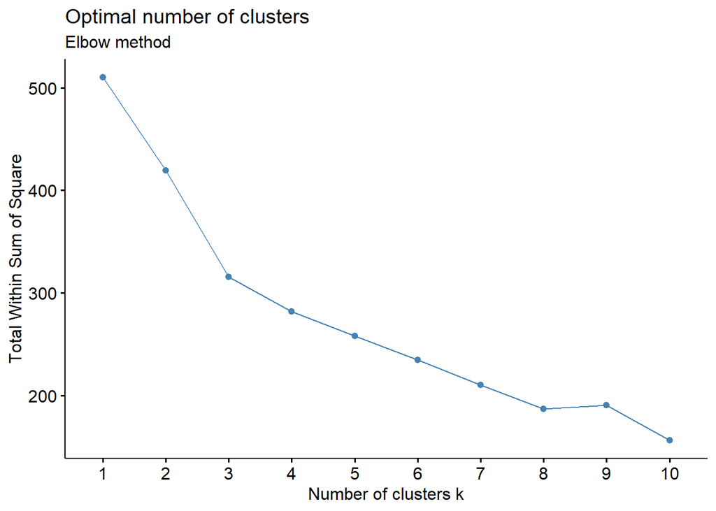

```r
g1 <- fviz_nbclust(town3, kmeans, method = 'wss') +
  labs(subtitle = 'Elbow method')
g1
```

Результат: 3 кластера

Метод “силуэтов”

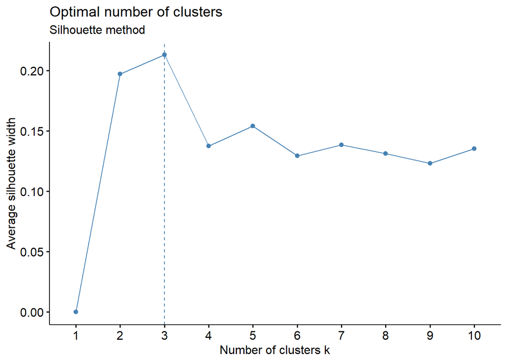

```r
g2 <- fviz_nbclust(town3, kmeans, method = 'silhouette') +
  labs(subtitle = 'Silhouette method')
g2
```

Результат 3 кластера

Метод “статистика разрыва”

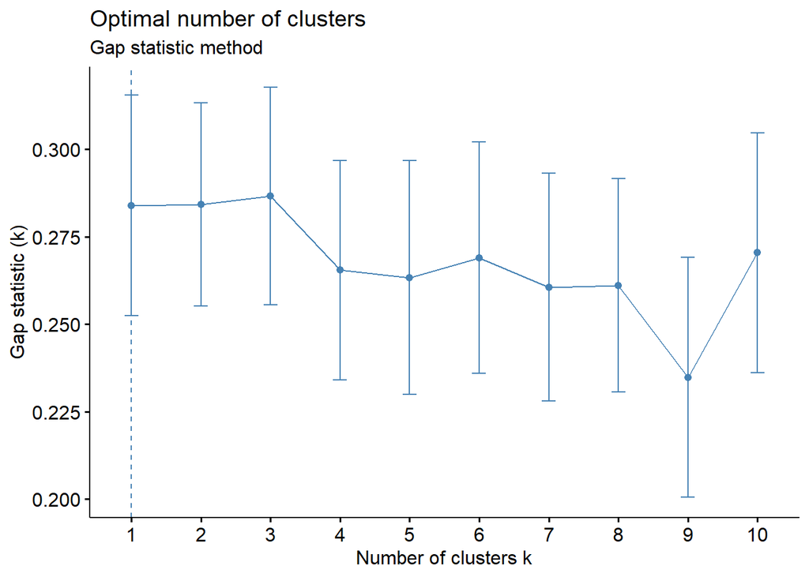

```r
g3 <- fviz_nbclust(town3, kmeans, method = 'gap_stat') +
  labs(subtitle = 'Gap statistic method')
g3
```

No comments

Иерархическая кластеризация

```r
town_dist <- dist(town3, method = 'euclidian')
```

Визуализация расстояний

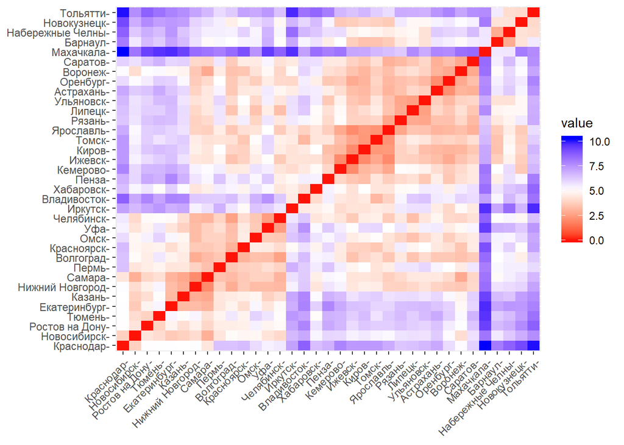

```r
fviz_dist(town_dist, order = TRUE, show_labels = TRUE, lab_size = NULL,
  gradient = list(low = "red", mid = "white", high = "blue"))
```

Результат: Высокий уровень “уникальности” городов: Махачкала, Тольятти, Набережные Челны и 2 кластера “близких” городов

выделение 3х кластеров

```r
town_hcl <- hcut(town3, k = 3,
                    hc_metric = 'euclidean', hc_method = 'ward.D2')
```

Построение дендограммы

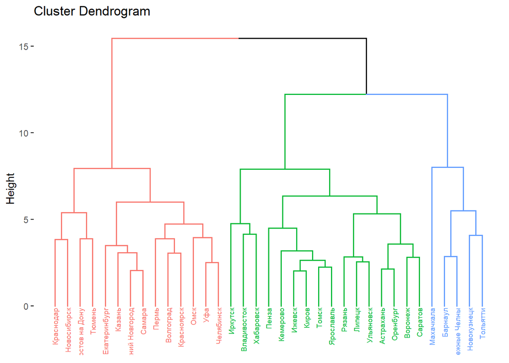

```r
fviz_dend(town_hcl,
          cex = 0.5, # размер подписи
          color_labels_by_k = TRUE) # цвет подписей по группам
```

На дендограмме также видно разбиение на 3 группы городов.

## 3.2 3.2 Разбиение на кластеры

Разбиение на кластеры методом главных компонент

```r
set.seed(7)
town_kmeans <- kmeans(town3, centers = 3)
town_pca <- prcomp(town3)
x <- summary(town_pca)
x
```

```
## Importance of components%s:
##                           PC1    PC2    PC3    PC4     PC5     PC6     PC7
## Standard deviation     2.1472 1.6888 1.3087 1.2457 0.96144 0.87217 0.76647
## Proportion of Variance 0.3074 0.1902 0.1142 0.1035 0.06162 0.05071 0.03917
## Cumulative Proportion  0.3074 0.4975 0.6117 0.7152 0.77678 0.82749 0.86666
##                            PC8    PC9    PC10    PC11    PC12    PC13
## Standard deviation     0.70488 0.6584 0.56170 0.51203 0.46685 0.39320
## Proportion of Variance 0.03312 0.0289 0.02103 0.01748 0.01453 0.01031
## Cumulative Proportion  0.89978 0.9287 0.94972 0.96720 0.98173 0.99203
##                           PC14    PC15
## Standard deviation     0.26942 0.21660
## Proportion of Variance 0.00484 0.00313
## Cumulative Proportion  0.99687 1.00000
```

По критерию Кайзера-Харриса оставляем первые 4 главные компоненты, у которых sd больше 1, на их долю приходится более 70% объясненной дисперсии. На первые 2 компоненты приходится 50% дисперсии.

Проверка гипотезы компактности

```r
library("cluster")
library('reshape2')
n <- dim(town3)[[1]]
euc.dist <- as.matrix(dist(town3))
dist = melt(euc.dist)
town3$cluster <- town_kmeans$cluster
pairs <- data.frame(dist = dist,
                    ca = as.vector(outer(1:n, 1:n,
                                         function(a, b) town3[a, 'cluster'])),
                    cb = as.vector(outer(1:n, 1:n,
                                         function(a, b) town3[b, 'cluster'])))
y <- dcast(pairs, ca ~ cb, value.var = 'dist.value', mean)
y
```

```
##   ca        1        2        3
## 1  1 4.191731 6.116253 7.018623
## 2  2 6.116253 3.778847 5.453664
## 3  3 7.018623 5.453664 4.009317
```

В полученной матрице расстояний у по главной диагонали приведены средние внутрикластерные расстояния, которые очевидно меньше, чем межкластерные расстояния (недиагональные элементы таблицы), т.е. гипотеза компактности выполняется и примененный алгоритм кластеризации результативен.

Визуализация данных в осях первых двух главных компонент.

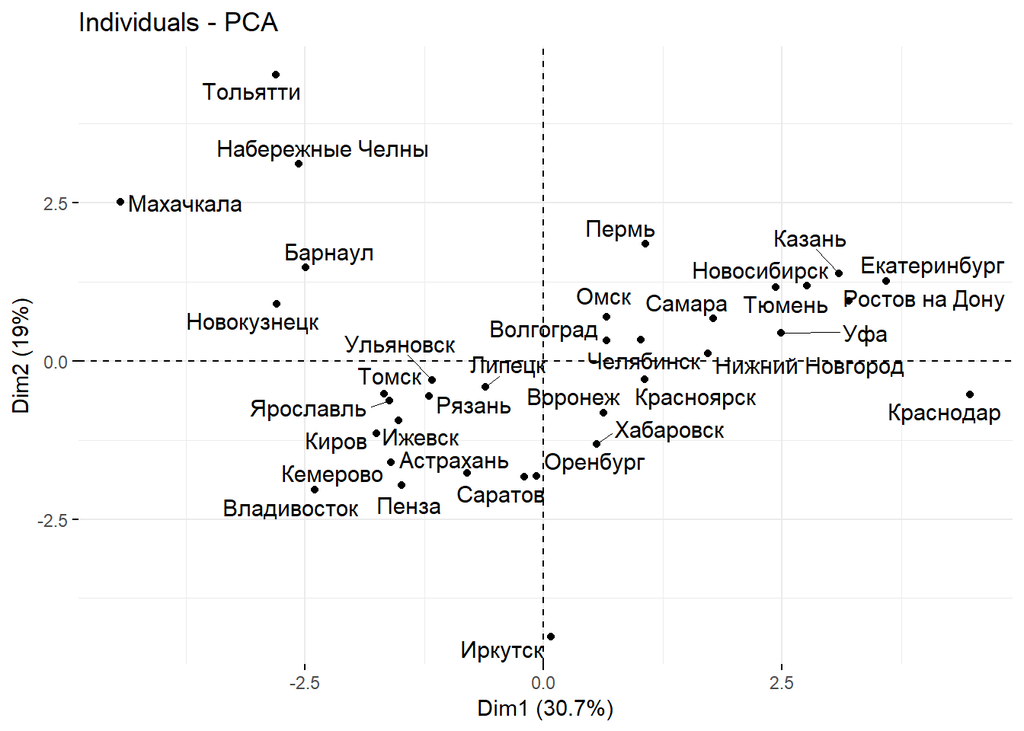

```r
fviz_pca_ind(town_pca, repel = TRUE)
```

Визуализация данных и проекция исходных переменных в осях главных компонент.

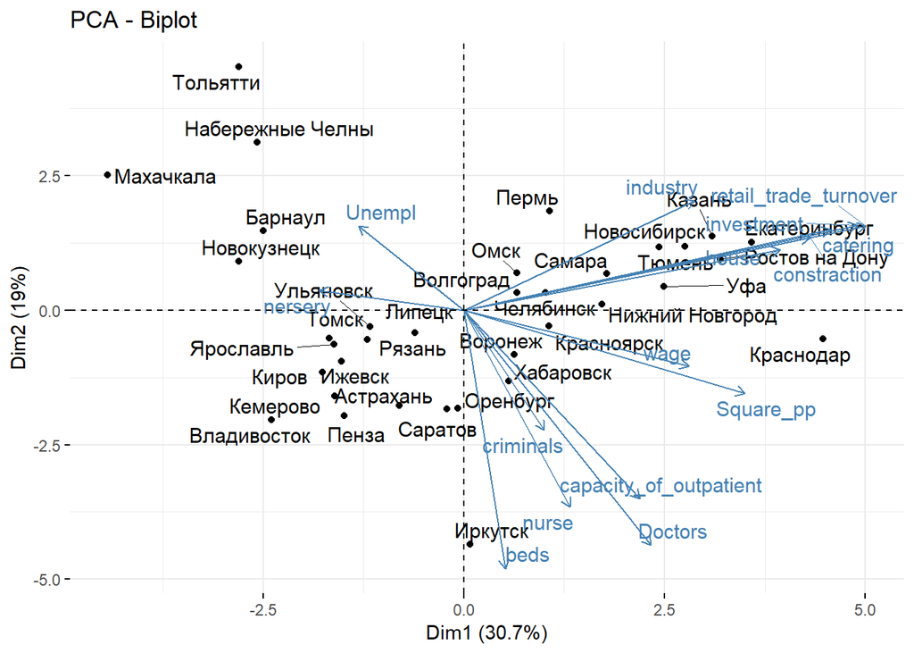

```r
fviz_pca_biplot(town_pca, repel = TRUE)
```

Вклад каждой переменной в первую ГК и вторую ГК соответственно

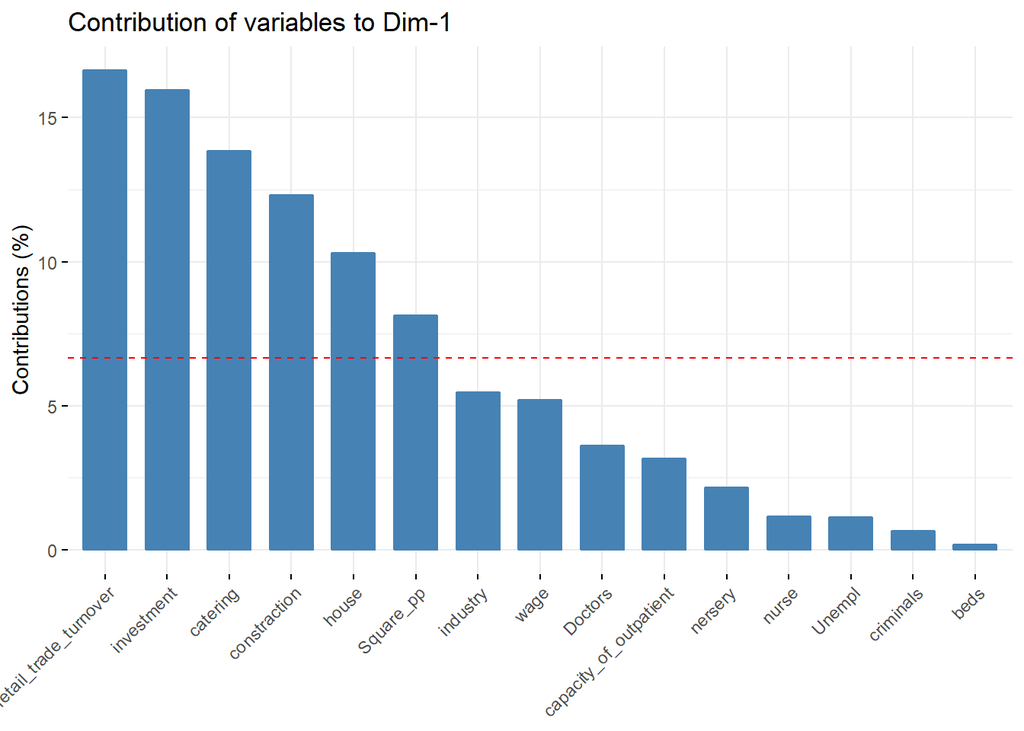

```r
fviz_contrib(town_pca, choice = 'var', axes = 1)
```

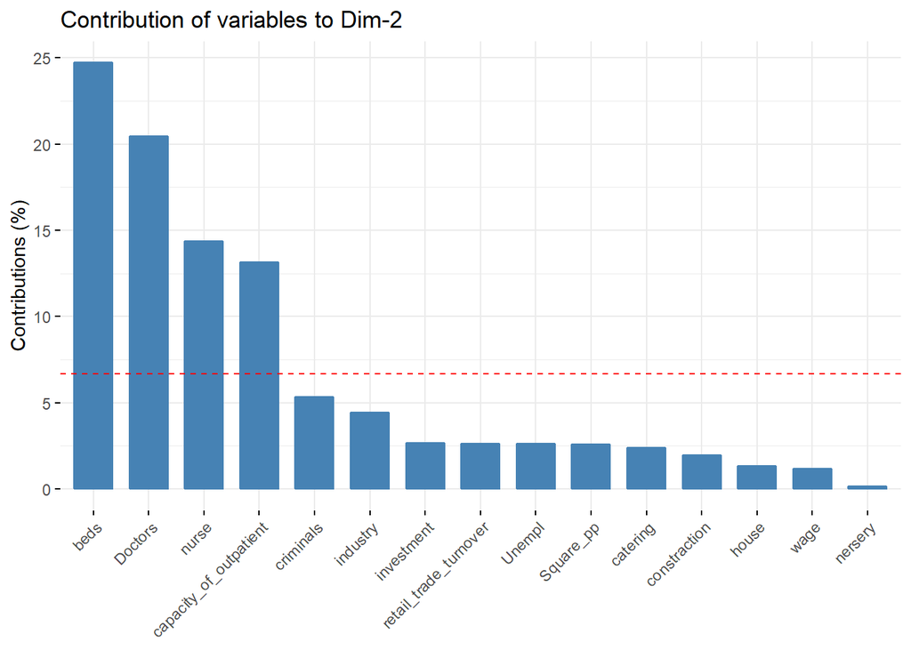

```r
fviz_contrib(town_pca, choice = 'var', axes = 2)
```

Визуализация данных в осях первых двух главных компонент и раскрашивание согласно кластерам:

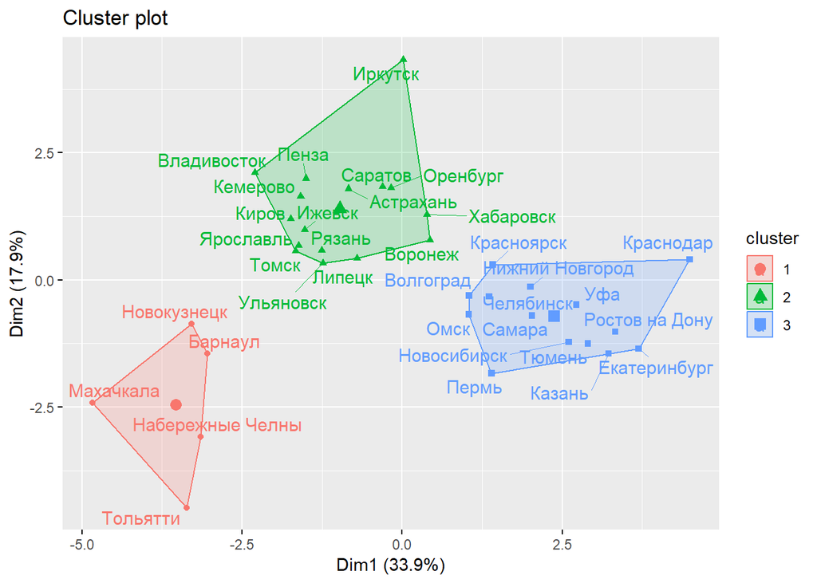

```r
fviz_cluster(object = town_kmeans,
             data = town3,
             ellipse.type = 'convex', repel = TRUE)
```

# 4 4. Оценка модели регрессии

```r
library(GGally) # больше готовых графиков
library(lmtest) # диагностика линейных моделей
library(sjstats) # удобные мелкие функции для работы с моделями
library(sandwich) # оценка Var для гетероскедастичности
library(AER) # работа с инструментальными переменными
```

Импорт данных по приросту населения по городам

```r
pop <- import('pop.xlsx') #прирост численности населения по городам
skim(pop)
```

```
## Skim summary statistics
##  n obs: 35
##  n variables: 3
##
## Variable type: character
##  variable missing complete  n min max empty n_unique
##      X__1       0       35 35   3  16     0       35
##
## Variable type: numeric
##    variable missing complete  n      mean        sd     p0      p25    p50
##         pop       0       35 35 823076.26 307172.41 510086 564513   642760
##  pop_growth       0       35 35   5022.91   6859.62  -7027   1326.5   3325
##      p75    p100     hist
##  1083949 1575613 ▇▁▁▁▂▁▁▁
##     5358   24171 ▁▃▇▂▂▁▁▁
```

```r
town4 <- left_join(town1, pop, by = "X__1")
```

## 4.1 4.1 Строим короткую модель: Изменение численности населения города в зависимости от ввода в действие жилых домов

```r
model_town <- lm(data = town4, pop_growth ~ house)
summary(model_town)
```

```
##
## Call:
## lm(formula = pop_growth ~ house, data = town4)
##
## Residuals:
##    Min     1Q Median     3Q    Max
##  -8565  -3186    452   2527   9933
##
## Coefficients:
##              Estimate Std. Error t value Pr(>|t|)
## (Intercept) -3371.653   1321.644  -2.551   0.0157 *
## house          13.261      1.747   7.593 1.19e-08 ***
## ---
## Signif. codes:  0 '***' 0.001 '**' 0.01 '*' 0.05 '.' 0.1 ' ' 1
##
## Residual standard error: 4224 on 32 degrees of freedom
##   (1 observation deleted due to missingness)
## Multiple R-squared:  0.6431, Adjusted R-squared:  0.6319
## F-statistic: 57.65 on 1 and 32 DF,  p-value: 1.192e-08
```

```r
tidy(model_town)
```

```
##          term    estimate   std.error statistic      p.value
## 1 (Intercept) -3371.65290 1321.643939 -2.551105 1.572048e-02
## 2       house    13.26114    1.746504  7.592963 1.192235e-08
```

Строим длинную модель: Изменение численности населения в зависимости от переменных: средний уровень з/п, ввод в действие жилых домов, уровень преступности.

```r
model_town_2 <- lm(data = town4, pop_growth ~ wage + house + criminals)
summary(model_town_2)
```

```
##
## Call:
## lm(formula = pop_growth ~ wage + house + criminals, data = town4)
##
## Residuals:
##     Min      1Q  Median      3Q     Max
## -8068.2 -2521.3    37.5  2085.3  5493.3
##
## Coefficients:
##               Estimate Std. Error t value Pr(>|t|)
## (Intercept) -2.001e+04  3.535e+03  -5.661 3.61e-06 ***
## wage         3.800e-01  1.172e-01   3.241  0.00291 **
## house        1.235e+01  1.374e+00   8.983 5.23e-10 ***
## criminals    2.298e+02  1.224e+02   1.878  0.07016 .
## ---
## Signif. codes:  0 '***' 0.001 '**' 0.01 '*' 0.05 '.' 0.1 ' ' 1
##
## Residual standard error: 3211 on 30 degrees of freedom
##   (1 observation deleted due to missingness)
## Multiple R-squared:  0.8067, Adjusted R-squared:  0.7873
## F-statistic: 41.73 on 3 and 30 DF,  p-value: 7.979e-11
```

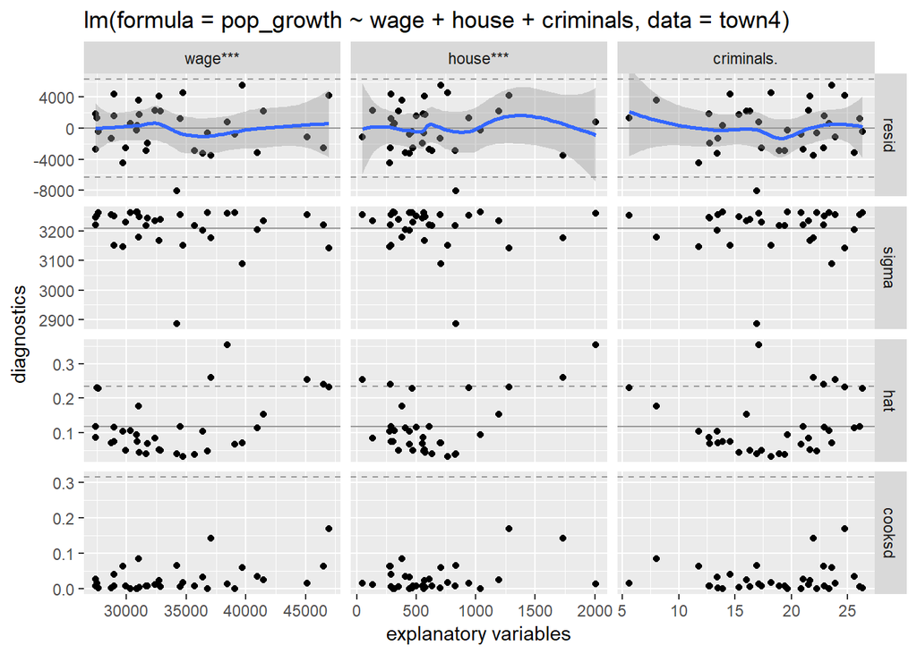

```r
ggnostic(model = model_town_2)
```

Тесты на значимость с учетом гетероскедастичности.

```r
coeftest(model_town_2, vcov. = vcovHC)
```

```
##
## t test of coefficients:
##
##                Estimate  Std. Error t value  Pr(>|t|)
## (Intercept) -2.0010e+04  3.7894e+03 -5.2805 1.055e-05 ***
## wage         3.8001e-01  1.0560e-01  3.5987  0.001135 **
## house        1.2345e+01  1.3634e+00  9.0548 4.384e-10 ***
## criminals    2.2979e+02  1.0950e+02  2.0984  0.044390 *
## ---
## Signif. codes:  0 '***' 0.001 '**' 0.01 '*' 0.05 '.' 0.1 ' ' 1
```

Доверительные интервалы с учетом гетероскедастичности

```r
coefci(model_town_2, vcov. = vcovHC)
```

```
##                     2.5 %        97.5 %
## (Intercept) -27748.681625 -1.227080e+04
## wage             0.164355  5.956669e-01
## house            9.560946  1.512988e+01
## criminals        6.150178  4.534259e+02
```

## 4.2 4.2 Сравнение двух моделей

```r
library('memisc')
mtable(model_town, model_town_2)
```

```
##
## Calls:
## model_town: lm(formula = pop_growth ~ house, data = town4)
## model_town_2: lm(formula = pop_growth ~ wage + house + criminals, data = town4)
##
## ======================================================
##                      model_town       model_town_2
## ------------------------------------------------------
##   (Intercept)         -3371.653*       -20009.742***
##                       (1321.644)        (3534.505)
##   house                  13.261***         12.345***
##                          (1.747)           (1.374)
##   wage                                      0.380**
##                                            (0.117)
##   criminals                               229.788
##                                          (122.369)
## ------------------------------------------------------
##   R-squared               0.643             0.807
##   adj. R-squared          0.632             0.787
##   sigma                4224.315          3210.849
##   F                      57.653            41.727
##   p                       0.000             0.000
##   Log-likelihood       -331.066          -320.642
##   Deviance        571034728.334     309286626.728
##   AIC                   668.132           651.284
##   BIC                   672.711           658.916
##   N                      34                34
## ======================================================
```

Сравнение моделей с учетом поправки на гетероскедасичность Гипотеза Н0: верна короткая модель

```r
waldtest(model_town, model_town_2, vcov = vcovHC)
```

```
## Wald test
##
## Model 1: pop_growth ~ house
## Model 2: pop_growth ~ wage + house + criminals
##   Res.Df Df      F    Pr(>F)
## 1     32
## 2     30  2 11.444 0.0002026 ***
## ---
## Signif. codes:  0 '***' 0.001 '**' 0.01 '*' 0.05 '.' 0.1 ' ' 1
```

По результатам теста Вальда гипотеза H0 отвергается. Выбираем модель 2.

# 5 5. Задача классификации

Для целей бинарной классификации разбиваем города на 2 кластера

```r
town_hcl <- hcut(town3, k = 2,
                    hc_metric = 'euclidean', hc_method = 'ward.D2')
```

Построение дендограммы

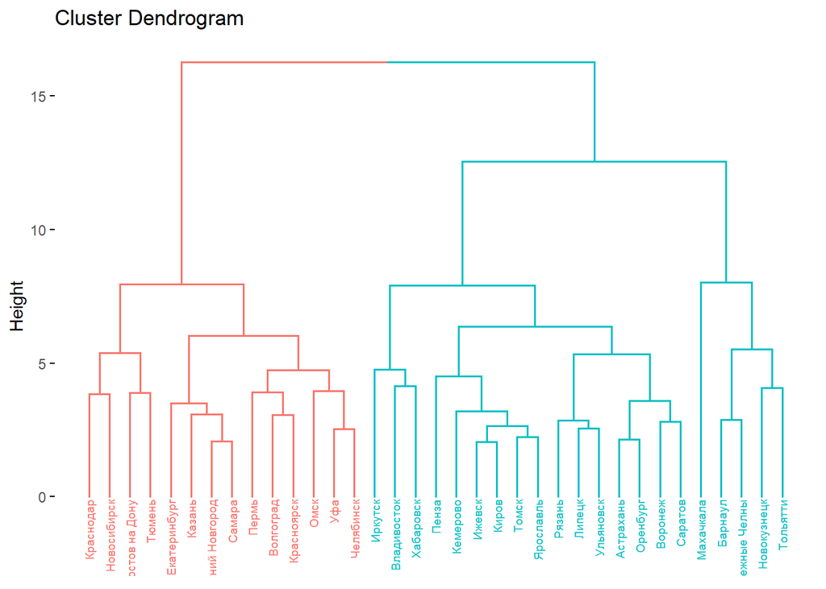

```r
fviz_dend(town_hcl,
          cex = 0.5, # размер подписи
          color_labels_by_k = TRUE) # цвет подписей по группам
```

```r
town_plus <- mutate(town4, cluster = town_hcl$cluster)
glimpse(town_plus)
```

```
## Observations: 35
## Variables: 22
## $ X__1                   <chr> "Астрахань", "Барнаул", "Владивосток", ...
## $ Unempl                 <dbl> 4.4724469, 2.6602884, 2.4557802, 5.1569...
## $ wage                   <dbl> 30908.0, 27433.4, 45138.7, 29902.4, 308...
## $ Square_pp              <dbl> 23.8, 22.8, 21.5, 23.1, 26.9, 24.4, 21....
## $ nersery                <dbl> 0.9330855, 0.9048913, 0.8632812, 0.9275...
## $ Doctors                <dbl> 91.3, 49.4, 89.5, 71.8, 86.7, 72.5, 78....
## $ nurse                  <dbl> 162.1, 96.7, 98.4, 131.4, 147.0, 121.5,...
## $ beds                   <dbl> 138.8, 89.9, 147.7, 119.8, 124.6, 136.9...
## $ capacity_of_outpatient <dbl> 293.6, 245.5, 258.9, 351.6, 276.1, 282....
## $ criminals              <dbl> 13.883769, 21.059546, 23.921352, 17.382...
## $ industry               <dbl> 162137.4, 78517.1, 11960.5, 450894.8, 1...
## $ constraction           <dbl> 9574.3, 8612.9, 506.2, 24431.7, 15910.0...
## $ house                  <dbl> 306.2, 608.6, 47.4, 475.1, 1039.2, 1196...
## $ retail_trade_turnover  <dbl> 42459.9, 61360.3, 4902.9, 98747.7, 1048...
## $ catering               <dbl> 779.3, 509.8, 814.1, 1531.5, 1652.0, 57...
## $ investment             <dbl> 82049.6, 18521.0, 6006.1, 101042.1, 632...
## $ transport              <fct> низкий, низкий, средний, высокий, средн...
## $ ecology                <fct> высокий, низкий, низкий, высокий, высок...
## $ innovation             <fct> низкий, средний, средний, средний, высо...
## $ pop_growth             <dbl> -980, 55, 2051, -1314, 8812, 16397, 147...
## $ pop                    <dbl> 532209, 635558, 605628, 1016794, 102797...
## $ cluster                <int> 1, 1, 1, 2, 1, 2, 1, 1, 2, 1, 1, 2, 2, ...
```

```r
town_fct <- mutate_if(town_plus, is.integer, factor)
glimpse(town_fct)
```

```
## Observations: 35
## Variables: 22
## $ X__1                   <chr> "Астрахань", "Барнаул", "Владивосток", ...
## $ Unempl                 <dbl> 4.4724469, 2.6602884, 2.4557802, 5.1569...
## $ wage                   <dbl> 30908.0, 27433.4, 45138.7, 29902.4, 308...
## $ Square_pp              <dbl> 23.8, 22.8, 21.5, 23.1, 26.9, 24.4, 21....
## $ nersery                <dbl> 0.9330855, 0.9048913, 0.8632812, 0.9275...
## $ Doctors                <dbl> 91.3, 49.4, 89.5, 71.8, 86.7, 72.5, 78....
## $ nurse                  <dbl> 162.1, 96.7, 98.4, 131.4, 147.0, 121.5,...
## $ beds                   <dbl> 138.8, 89.9, 147.7, 119.8, 124.6, 136.9...
## $ capacity_of_outpatient <dbl> 293.6, 245.5, 258.9, 351.6, 276.1, 282....
## $ criminals              <dbl> 13.883769, 21.059546, 23.921352, 17.382...
## $ industry               <dbl> 162137.4, 78517.1, 11960.5, 450894.8, 1...
## $ constraction           <dbl> 9574.3, 8612.9, 506.2, 24431.7, 15910.0...
## $ house                  <dbl> 306.2, 608.6, 47.4, 475.1, 1039.2, 1196...
## $ retail_trade_turnover  <dbl> 42459.9, 61360.3, 4902.9, 98747.7, 1048...
## $ catering               <dbl> 779.3, 509.8, 814.1, 1531.5, 1652.0, 57...
## $ investment             <dbl> 82049.6, 18521.0, 6006.1, 101042.1, 632...
## $ transport              <fct> низкий, низкий, средний, высокий, средн...
## $ ecology                <fct> высокий, низкий, низкий, высокий, высок...
## $ innovation             <fct> низкий, средний, средний, средний, высо...
## $ pop_growth             <dbl> -980, 55, 2051, -1314, 8812, 16397, 147...
## $ pop                    <dbl> 532209, 635558, 605628, 1016794, 102797...
## $ cluster                <fct> 1, 1, 1, 2, 1, 2, 1, 1, 2, 1, 1, 2, 2, ...
```

## 5.1 5.1 Создадим вектор train_rows с номерами строк для обучающей части.

```r
library(caret)
set.seed(777)
train_rows <- createDataPartition(town_fct$cluster, p = 0.8, list = FALSE)
town_train <- town_fct[train_rows, ]
town_test <- town_fct[train_rows, ]
```

## 5.2 5.2 Строим логистическую регрессию для набора данных `town_train`.

```r
town_lmodel <- train(data = town_train, cluster ~ pop, family = binomial(link = 'logit'), method ='glm')
summary(town_lmodel)
```

```
##
## Call:
## NULL
##
## Deviance Residuals:
##      Min        1Q    Median        3Q       Max
## -1.52724  -0.24507  -0.12742   0.04238   1.89937
##
## Coefficients:
##               Estimate Std. Error z value Pr(>|z|)
## (Intercept) -1.441e+01  5.997e+00  -2.403   0.0163 *
## pop          1.804e-05  7.935e-06   2.273   0.0230 *
## ---
## Signif. codes:  0 '***' 0.001 '**' 0.01 '*' 0.05 '.' 0.1 ' ' 1
##
## (Dispersion parameter for binomial family taken to be 1)
##
##     Null deviance: 39.3361  on 28  degrees of freedom
## Residual deviance:  7.8637  on 27  degrees of freedom
## AIC: 11.864
##
## Number of Fisher Scoring iterations: 7
```

Cтроим прогноз модели для тестовых данных `town_test`.

```r
town_pred <- predict(town_lmodel, newdata = town_test)
head(town_pred)
```

```
## [1] 1 1 2 2 1 1
## Levels: 1 2
```

```r
glimpse(town_pred)
```

```
##  Factor w/ 2 levels "1","2": 1 1 2 2 1 1 2 1 2 2 ...
```

```r
town_prob <- predict(town_lmodel, newdata = town_test, type = 'prob')
head(town_prob)
```

```
##              1           2
## 1 9.919146e-01 0.008085376
## 3 9.702620e-01 0.029738018
## 4 1.922599e-02 0.980774007
## 6 1.014335e-05 0.999989857
## 7 9.434969e-01 0.056503074
## 8 9.606113e-01 0.039388697
```

Оценка качества прогноза

```r
confusionMatrix(data = town_pred, reference = town_test$cluster)
```

```
## Confusion Matrix and Statistics
##
##           Reference
## Prediction  1  2
##          1 16  1
##          2  1 11
##
##                Accuracy : 0.931
##                  95% CI : (0.7723, 0.9915)
##     No Information Rate : 0.5862
##     P-Value [Acc > NIR] : 4.2e-05
##
##                   Kappa : 0.8578
##  Mcnemar's Test P-Value : 1
##
##             Sensitivity : 0.9412
##             Specificity : 0.9167
##          Pos Pred Value : 0.9412
##          Neg Pred Value : 0.9167
##              Prevalence : 0.5862
##          Detection Rate : 0.5517
##    Detection Prevalence : 0.5862
##       Balanced Accuracy : 0.9289
##
##        'Positive' Class : 1
##
```

## 5.3 5.3 Строим ROC кривую

```r
town_test_set <- data.frame('1' = town_prob$'1',
                        '2' = town_prob$'2',
                        pred = town_pred,
                        obs = town_test$cluster)
glimpse(town_test_set)
```

```
## Observations: 29
## Variables: 4
## $ X1   <dbl> 9.919146e-01, 9.702620e-01, 1.922599e-02, 1.014335e-05, 9...
## $ X2   <dbl> 0.008085376, 0.029738018, 0.980774007, 0.999989857, 0.056...
## $ pred <fct> 1, 1, 2, 2, 1, 1, 2, 1, 2, 2, 1, 1, 2, 1, 2, 1, 1, 2, 1, ...
## $ obs  <fct> 1, 1, 2, 2, 1, 1, 2, 1, 2, 2, 1, 1, 2, 1, 2, 1, 1, 2, 1, ...
```

```r
glimpse(town_test$cluster)
```

```
##  Factor w/ 2 levels "1","2": 1 1 2 2 1 1 2 1 2 2 ...
```

```r
prSummary(town_test_set, lev = levels(town_test_set$obs))
```

```
##       AUC Precision    Recall         F
##        NA 0.9411765 0.9411765 0.9411765
```

```r
#twoClassSummary(town_test_set, lev = levels(town_test_set$obs))
```

[figure not shown]

```r
ggplot(town_test_set, aes(d = obs, m = 1)) + geom_roc(n.cuts = 0)
```